# IMPACT R Mentor training

# Not a smooth ride

## Questions!

- questions are everything!

## This is a Pilot

- Stuff will go wrong
- I need your feedback
- No one in the humanitarian system has (successfully) done this before

# General Strategy

## Data Unit Strategy:

- More work => Deeper Analysis
- More work => Fewer Errors
- More work => Less Work

## Components

- Culture
- **Capacity**
- Processes
- Sustainable Change

# Data Unit capacity building framework

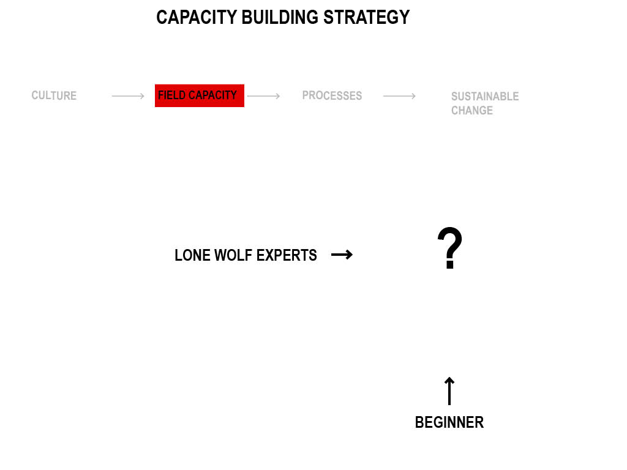

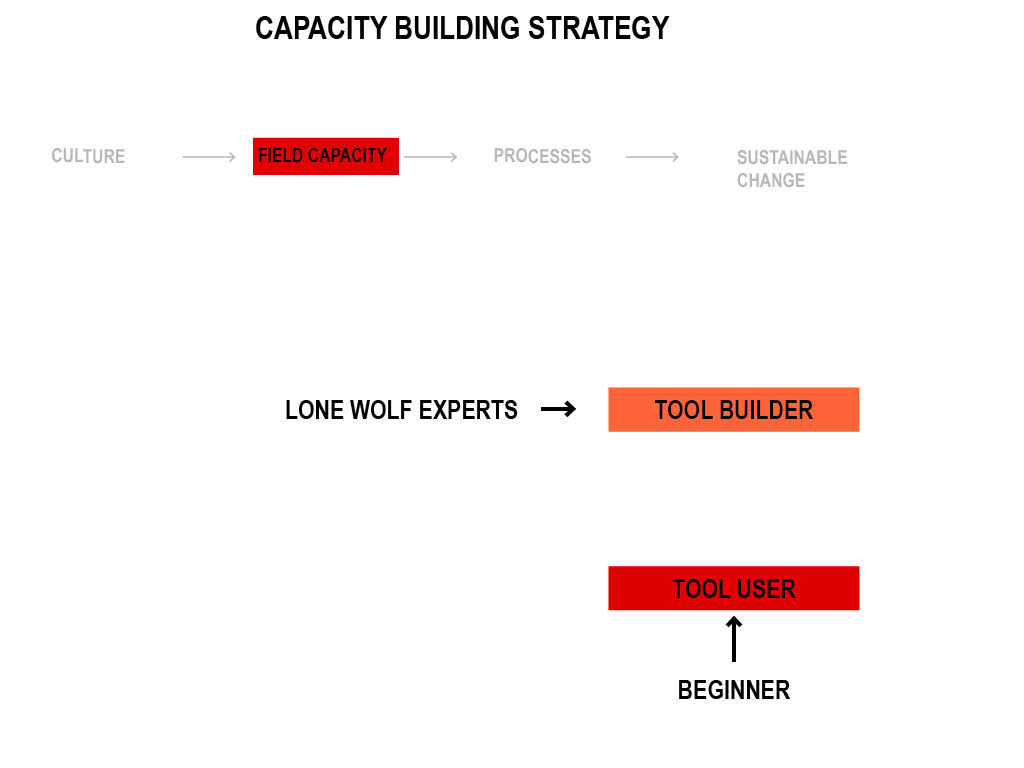

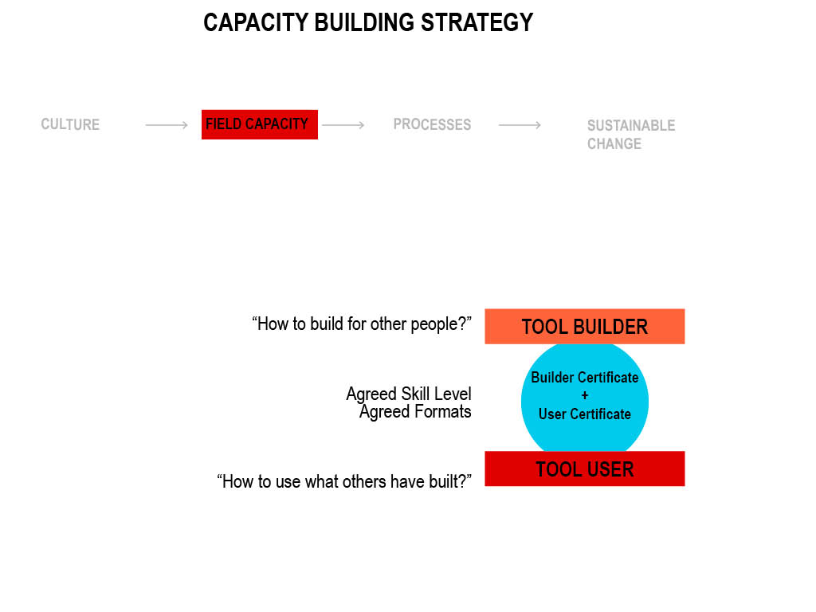

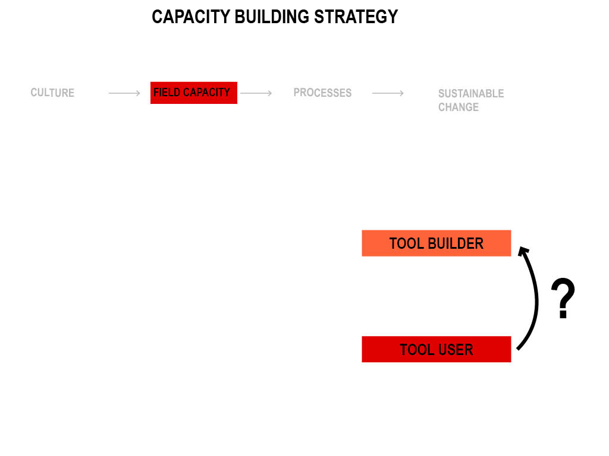

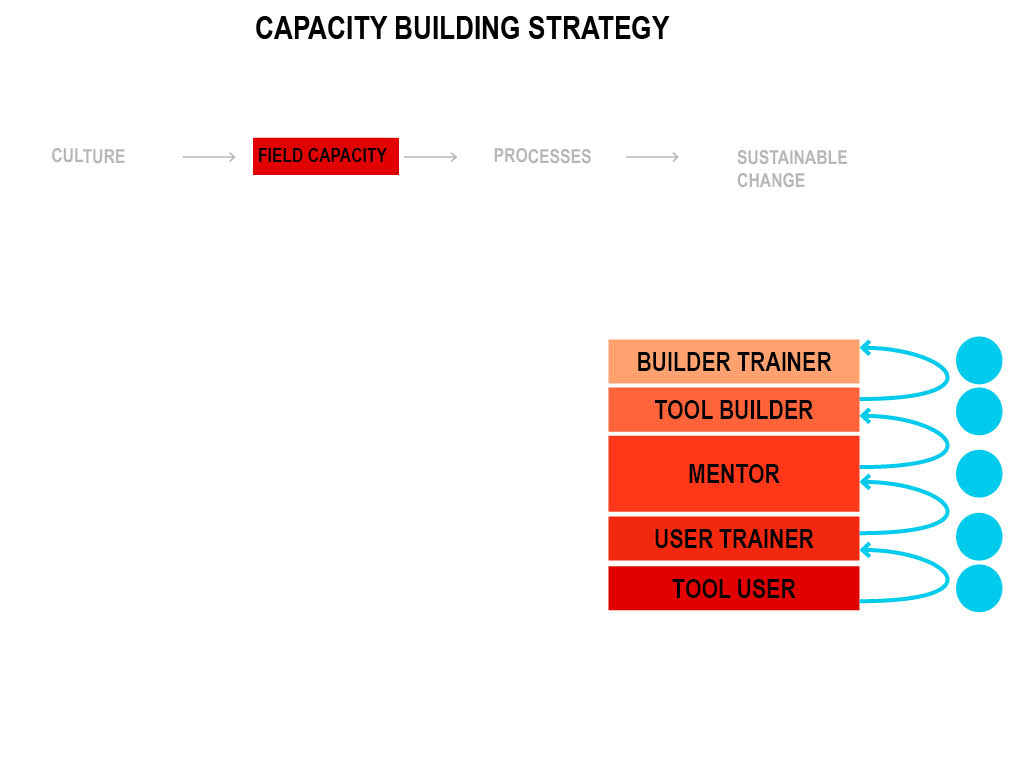

# Learning Goals

## NOT the learning Goals

- *Not* a training on specific tools
- *Not* a data science degree in 2 days
  - (not statistics)
  - (not generic R)
  - (not quantitative research methods)

# What it means to be an R-Mentor

# R-Users

## R-User skills summary

- Loading packages
- Reading documentation
- Executing functions
- Vers basic debugging (reading and googling error messages)

## trainer training

- Teach people how to do those things
- Realise how much you already know (starting with console)

## Setting up Version Control for your project

- GitHub - Forking vs. Branching - Make a fork for the hypegrammaR package, from the training branch and pull - Raise an issue

## Setting up Version Control for your project: commits

- Valuable commit messages (i.e. not what Eliora does) ##

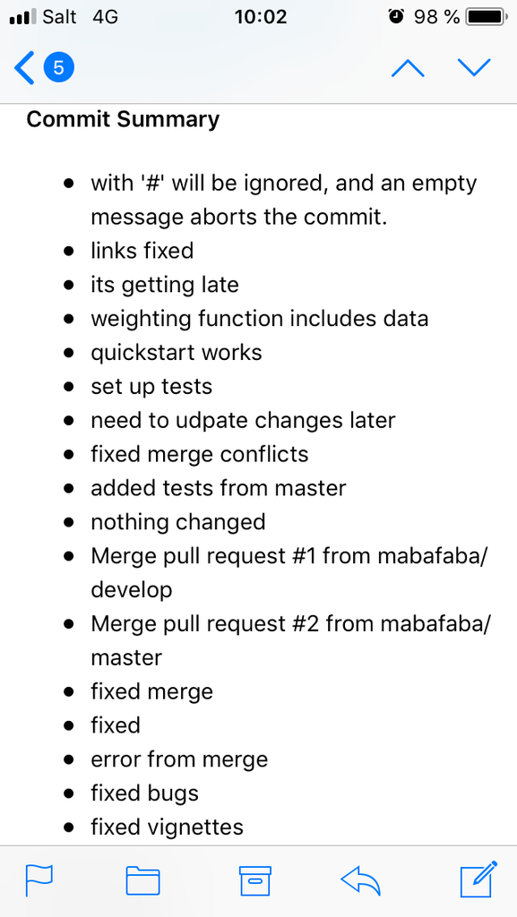

# Portable Code / Projects

## R environments overview

```
List at least three ways that an environment is different to a list.

What is the enclosing environment of a function? Why is it important?

How do you determine the environment from which a function was called?

How are <- and <<- different?
```

## The rmarkdown environment

BASICALLY Rmarkdown knits into its own funky fresh environment

## R environments answers

[output not shown]

# Debugging

## Debugging techniques

- Russian dolls ##

[figure not shown]

## Debugging techniques

- Manual debugging
- Loops are hard to debug: Assign intermediate steps to an object
- Print variable name
- Reduce to inputs a list of two elements
- install.packages(“debug”) library(debug)

## Debugging techniques

- Debug - > On error -> Error inspector / Break in code

## Debugging techniques

- Generating fake inputs
  - Have the code for this readily available

[output not shown]

## Debugging techniques: Common bugs

- [List][https://docs.google.com/document/d/1KX_lwlagsn3kd5a1DCsdcle69kUTBoHWD4tyMHHMnjo/edit?usp=drive_web&ouid=108086624168702718242]
- Look on stackoverflow
- Raise the issue

## Debugging in R markdown

When the interactive debugger shows up in the console, it will not print user output. If you want to see output in the console, you should use sink().

## Common Error Messages and what they mean

# Modern R

## Tidyverse

[Tidy Data][https://r4ds.had.co.nz/tidy-data.html]

- Packages in the tidyverse

[dplyr][https://dplyr.tidyverse.org/] [tibble][https://tibble.tidyverse.org/] [ggplot2][https://ggplot2.tidyverse.org/] [purrr][https://purr.tidyverse.org/]

## Apply / purrr

- Loops = Bad - Apply is vectorised

# Software Design: Functions

## Writing functions with tests

##

[figure not shown]

## Writing functions with tests

Why do we write tests before we write our code ?

## Writing functions with tests

Pull the latest hypegrammaR, and add tests for the map_to_summary_table function

## pure functions

[Pure Functions][https://dev.to/chrisvasqm/explain-pure-functions-like-im-five-26o6]

## Decoupling and Cohesion

## Good function names

# Good Practice

## Why write “good” code?

## Naming things

## Documentation

## DRY design

# Contributing to R packages

## Reading Package Source Code

## Do’s and don’ts for packages source code

- pure functions only
- forbidden:
  - `source()`
  - `library()`
  - `require()`
- roxygen documentation

## Collaborating on GitHub: talk - fork - clone - edit - pull request